**Sénoville Scilia**

# *NoteBook Calcul Scientifique: Simulation de la réponse de pièces viscoélastiques à un chargement complexe*

Le travail présenté dans ce NoteBook s'insère dans le cadre de l'UE de Calcul Scientifique. On définit les matériaux viscoélastiques dans le cadre général des matériaux complexes, c'est à dire des matériaux pour lesquels les propriétés élastiques dépendent de la fréquence de sollicitation. En effet, les matériaux viscoélastiques se distinguent des matériaux élastiques par leur réponse *différée* lorsqu'ils sont sollicités (ex: polymères ou les tissus matériaux élastiques) contrairement aux matériaux élastiques qui ont une réponse instantanée(ex: céramiques et des matériaux métalliques). De ce fait, les notions de chargement et de temps interviennent dans la définition d'un comportement viscoélastique. Nous avons donc tout interêt à s'intéresser aux *histoires de chargement et de réponse* au lieu de s'intéresser à une valeur ponctuelle, fixée dans le temps, de la réponse et de la déformation.

Le projet que nous avons choisi, consiste donc en l'étude de la simulation de la réponse d’un matériau viscoélastique à une histoire de chargement donné dans le cas de la viscoélasticité linéaire sans vieillissement (principe de superposition de Boltzmann valide et propriétés mécaniques du matériau n’évoluant pas au cours du temps). Pour se faire, on utilisera des modèles rhéologiques élémentaires mais aussi plus complexes afin de prévoir les réponses en fluage et en relaxation des matériaux. Ainsi, dans un premier temps nous avons simulé numériquement un test d’Analyse Mécanique Dynamique (DMA) pour un matériau obéissant à un modèle de Maxwell, puis dans une seconde partie, nous nous sommes intéressées à l'étude du cas de fluage et de relaxation au formalisme similaire pour le modèle de Zener pour enfin proposer une sollicitation non plus sous-forme cyclique mais sous-forme polynomiale.

*N.B: On traitera ici uniquement le problème en une dimension où on ne manipule que des fonctions scalaires (contraintes et déformations unidirectionnelles σ et ε, fonction de relaxation r ...)*

```python
import numpy as np
import matplotlib.pyplot as plt
```

## **Partie 1: Simulation numérique d'un test de DMA - modèle de Maxwell**

Les paramètres $\epsilon_{0}$, $\omega$, E, $\eta$, $\tau$ sont fixés à 1 dans cette partie

### 1. Description d'un test DMA

Ici, nous n’allons pas considérer un simple essai de relaxation (essai statique avec sollicitation en déplacement et réponse en contrainte) mais un autre type d’essai appelé *dynamique* où la sollicitation imposée varie périodiquement avec le temps. C’est d’ailleurs le DMA de ce matériau qui va imposer ce chargement en déplacement cyclique (une sinusoïde) en contrôlant la fréquence d’excitation (pulsation $\omega$) et qui va nous permettre l’étude et la caractérisation des propriétés mécaniques des matériaux viscoélastiques.

Lors d'une mesure mécanique dynamique, un déplacement sinusoïdal est appliqué à une fréquence f. Le signal de déplacement peut s'écrire :

$$\epsilon(t) = \epsilon_{0}sin(\omega t)$$

avec $\epsilon_{0}$, l'amplitude du cycle de déplacement  
avec $\omega$=2$\pi$f, la pulsation en rad/s  
avec $t$, le temps en seconde

```python
t=np.linspace(0,100,10000)
epsilon_0=1
w=1

epsilon_t=epsilon_0*np.sin(w*t)

plt.plot(t,epsilon_t,'g')
plt.title('Fig 1: Sollicitation en déplacement d un materiau viscoélastique $\epsilon(t)$')
plt.xlabel('t')
plt.ylabel('$\epsilon(t)$')
plt.show()
```

Le signal de réponse en contrainte d'un matériau viscoélastique est déphasé (car ce dernier dissipe une partie de l'énergie en se déformant), soit :

$$\sigma(t) = \sigma_{0}sin(\omega t + \delta)~~~~~~~~~~~~~~(1)$$

avec $\sigma_{0}$, l'amplitude du cycle de contrainte

### 2. Modèles rhéologiques

#### a) Généralités

Il est nécessaire d'adopter une modélisation mécanique analogique afin de modéliser au mieux le comportement mécanique des milieux viscoélastiques. De ce fait, il est possible de décrire le comportement viscoélastique d'un milieu à l'aide des ressorts et d'amortisseurs. On associe donc le caractère élastique du milieu aux ressorts de module d'élasticité (module d' Young) E et le caractère visqueux aux amortisseurs de viscosité $\eta$. Ces deux grandeurs sont des constantes indépendantes du temps qui nous seront indispensables pour la caractérisation des propriétés physiques du matériau.

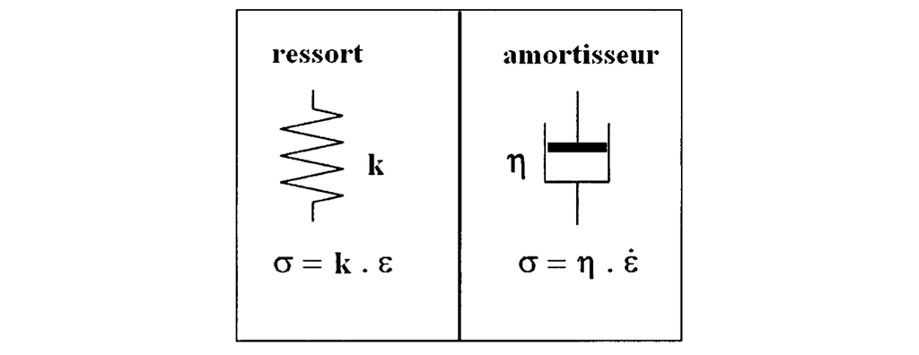

Fig 2: Relations reliant la contrainte à la déformation pour un ressort d'élasticité E et pour un amortisseur de viscosité $\eta$

Les équations servant à caractériser les circuits électriques sont également utilisées afin de décrire les modèles mécaniques. En effet, les ressorts sont équivalents aux condensateurs (emmagasinent une énergie mécanique statique récupérable) tandis que les amortisseurs visqueux sont équivalents aux résistances ohmiques dans les circuits électriques (dissipent l'énergie mécanique en chaleur par frottement). On peut alors définir différents modèles mécaniques en fonction des associations en série et/ou en parallèles des éléments mécaniques.

#### b) Modèle de Maxwell

Le modèle rhéologique élémentaire que nous allons utilisé ici est celui de Maxwell.

Dans ce modèle, un ressort et un amortisseur sont montés en série comme l'indique la figure 3.

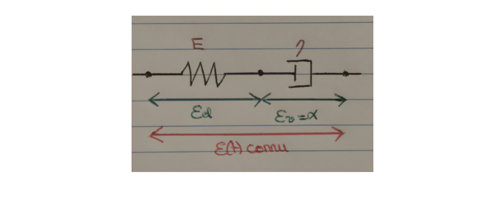

Fig 3: Représentation du modèle de Maxwell

Sous l'action d'une contrainte $\sigma(t)$, le ressort se déforme de $\epsilon_{el}(t)$ et l'amortisseur de $\epsilon_{v}(t)$ pour donner naissance à une déformation totale $\epsilon (t)$ qui est la somme des deux. La contrainte dans le ressort obéit à la loi de Hooke et celle dans l'amortisseur suit la loi de Newton.

D'après les lois d'association en série du déplacement et de la contrainte totale, nous avons:

$$\epsilon(t) = \epsilon_{el} + \epsilon_{v}$$

$$\sigma(t) = \sigma_{el} = \sigma_{v} ⇔ \sigma(t) = E\epsilon_{el} + \eta d\epsilon_{v}/dt$$

or, nous sommes dans le cas d'un chargement cyclique, donc:

$$\epsilon(t) = \epsilon_{el} + \epsilon_{v} = \epsilon_{0}sin(\omega t)$$

De ce fait, la réponse en contrainte obéit à l'équation différentielle suivante:

$$\frac{\mathrm{d}\sigma(t)}{\mathrm{d}t} + \frac{1}{\tau} \sigma(t) = E \omega \epsilon_{0}cos(\omega t)$$

avec $$\tau=\frac{\eta}E$$ correspondant au temps caractéristique de relaxation du matériau.

Pour déterminer la réponse en contrainte, nous avons donc le choix soit de passer par la formulation intégrale de l'expression précédente, soit d'utiliser la formulation incrémentale. C'est cette dernière méthode que nous allons exploiter ici. En effet, la dépendance à l’histoire de chargement peut être décrite à l’aide de variables d’état supplémentaires $\alpha(t)$

On pose: $$\alpha = \epsilon_{v}$$

donc: $$\sigma(t) = \sigma_{el} = E (\epsilon(t) - \alpha)~~~~~~~~~~~~~~~~~(2)$$

avec $\alpha$(0)=0 car il n'y a pas de déformation instantanée

Afin de résoudre cette équation différentielle non-homogène à coefficient constant d'ordre 1, on utilise un schéma d'intégration de type Euler pour t ∈ [0, t<sub>max</sub>] avec t<sub>max</sub>=100

La méthode d'Euler se définit ici par:

$$\Longrightarrow \boxed{\alpha_{n+1} \simeq \alpha_n + \frac{\Delta t}{\tau} (\epsilon - \alpha_n)}$$

```python
tau=1
w=1

def euler_m(dt, tmax):
    m=int(tmax/dt)

    alpha_t_num=np.zeros(m)
    alpha_t_num[0]=0
    for i in range (1,m):
        alpha_t_num[i]=alpha_t_num[i-1] + dt*(epsilon_t[i]-alpha_t_num[i-1])/tau
    return alpha_t_num
```

```python
alpha_t_num = euler_m(0.01,100)
```

En remplaçant la valeur trouvée numériquement de $\alpha(t)$ dans l'équation (2), on obtient la courbe suivante (figure 4) illustrant l'équation de la réponse en contrainte:

```python
sigma_t_num_m = E*(epsilon_t - alpha_t_num)

plt.plot(t, sigma_t_num_m,'b')
plt.title('Fig 4: Réponse en contrainte d un materiau viscoélastique $\sigma_{num}(t)$ via le modèle de Maxwell-résolution numérique')
plt.xlabel('t')
plt.ylabel('$\sigma_{num}(t)$')
plt.show()
```

Comme le résultat (1) de l'essai de DNA l'atteste, on obtient bien une courbe sinusoidale pour la réponse en contrainte. De plus, cet essai nous montre que cette dernière est déphasée par rapport à la courbe représentant la sollicitation en déplacement d'un déphasage noté $\delta$. C'est bien ce que l'on obtient sur la figure 5:

```python
plt.plot(t,sigma_t_num_m,'b',label='$\sigma_{num}(t)$')
plt.plot(t,epsilon_t,'g',label='$\epsilon(t)$')
plt.title('Fig 5: Sollicitation en déplacement et réponse en contrainte d un materiau viscoélastique via le modèle de Maxwell-résolution numérique')
plt.legend()
plt.xlabel('t')
plt.xlim(0,20)
plt.show()
```

On peut également valider cette solution numérique en la comparant à la solution analytique déterminable dans ce cas de situation (la fonction sinusoidale étant une fonction usuelle).

```python
E=1
w=1
tau=1

alpha_t_anal=((1/tau)**2*np.sin(w*t)-1/tau*w*np.cos(w*t)+w/(tau*np.exp(t/tau)))/(w**2+(1/tau)**2)
sigma_t_anal_m=E*(epsilon_t-alpha_t_anal)
```

On compare alors la courbe obtenue analytiquement avec la courbe numérique sur la figure 6:

```python
plt.plot(t, sigma_t_num_m,'b',label='$\sigma_{num}(t)$')
plt.plot(t, sigma_t_anal_m,'r',label='$\sigma_{anal}(t)$')
plt.title('Fig 6: Réponse en contrainte d un materiau viscoélastique via la résolution numérique et analytique (modèle de Maxwell)')
plt.xlabel('t')
plt.xlim(0,20)
plt.legend()
plt.show()
```

La superposition parfaite de ces deux courbes nous permet donc de valider la solution numérique de la réponse en contrainte obtenue précédemment.

Il nous est également possible de tracer la contrainte en fonction de la déformation.

```python
plt.plot(epsilon_t,sigma_t_anal_m)
plt.title('Fig 7: Courbe contrainte-déformation -modèle de Maxwell')
plt.xlabel('$\epsilon(t)$')
plt.ylabel('$\sigma_{anal}(t)$')
plt.show()
```

Cette courbe prend l'allure d'une ellipse qui traduit un phénomène d'hystérésis caractéristque d'un matériau viscoélastique. La zone délimitée par les courbes de chargement et déchargement d’une boucle d’hystérésis correspond à l’énergie dissipée sous forme de chaleur au cours d’un cycle.

### 3. Tests

La présence du déphasage $\delta$ n'est pas anodine dans l'équation (1). En effet, celui ci est caractéristique d'un comportement viscoélastique. La contrainte est en retard par rapport à la déformation imposée (relaxation de la contrainte). II y a une dissipation d'énergie en chaleur par frottements internes dûe à la présence de l'amortisseur visqueux (comme expliqué précédemment). De ce fait, on en déduit que pour un déphasage nul, le matériau a un comportement purement élastique (loi de Hooke) puisque l'on supprime dans ce cas, l'amortisseur responsable de ce déphasage.

Nous avons vu précédemment que le caractère purement élastique d'un milieu est définit par son module d'élasticité E. En effet, la loi de Hooke permet de lier la contrainte au déplacement via le module de Young. De ce fait la courbe contrainte-déformation fait apparaitre une droite linéaire dont le coefficient de proportionnalité correspond à E.

D'autre part, nous avons vu que le caractère visqueux d'un milieu est définit par son module de viscosité $\eta$. En effet, la contrainte est lié dans ce cas au taux de déformation (ou vitesse de déformation). De ce fait, la courbe contrainte-vitesse de déformation fait également apparaitre une droite linéaire dont le coeffcient de proportionnalité est $\eta$.

Différents régimes peuvent donc etre définis: le régime purement élastique, le régime visqueux ainsi que le régime viscoélastique. Dans cette partie, nous allons considérer deux cas limites: le solide élastique et le liquide visqueux en faisant varier deux paramètres du problème: la pulsation $\omega$ et le temps caractéristique de relaxation $\tau$ ainsi qu'en déterminant leur intéraction.

Le premier test consiste à fixer une valeur de $\frac{1}{\omega}$ très supérieure devant le temps caractéristique $\tau$. De ce fait, on se trouve dans le cas des basses fréquences ou au temps long. On trace alors en premier lieu, la réponse en contrainte en fonction du temps dans ce cas particulier (voir figure 8).

```python
t=np.linspace(0,1000)
w=0.01

epsilon_t=epsilon_0*np.sin(w*t)

alpha_t_anal=((1/tau)**2*np.sin(w*t)-1/tau*w*np.cos(w*t)+w/(tau*np.exp(t/tau)))/(w**2+(1/tau)**2)
sigma_t_anal_m=E*(epsilon_t-alpha_t_anal)

plt.plot(t,sigma_t_anal_m,'r')
plt.title("Fig 8: Réponse en contrainte d un materiau viscoélastique via le modèle de Maxwell $\sigma_{anal}(t)$ au temps long")
plt.xlabel('t')
plt.ylabel('$\sigma_{anal}(t)$')
plt.show()
```

Le début de la courbe correspond au régime transitoire. Il s'agit du régime d'évolution du système qui n'a pas encore atteint un état stable. Il est caractérisé par le temps caractéristique de relaxation défini précédemment.

Pour déterminer le régime dans lequel on se trouve dans le cas des basses fréquences ou temps long, on décide de calculer la dérivée de la sollicitation en déplacement.

```python
der_epsilon_t=epsilon_0*w*np.cos(w*t)
```

En traçant la contrainte en fonction du taux de déformation, on obtient la figure 9 ci-dessous:

```python
plt.plot(der_epsilon_t,sigma_t_anal_m)
plt.title('Fig 9: Contrainte en fonction de la vitesse de déformations au temps long via le modèle de Maxwell')
plt.xlabel('d$\epsilon(t)$/dt')
plt.ylabel('$\sigma_{anal}(t)$')
plt.show()
```

On obtient donc une droite linéaire. On en déduit donc que la contrainte et le taux de déformation sont liés par un coeffcient de proportionnalité qui n'est autre que $\eta$. On en déduit donc qu'en basse fréquence ($\omega$<<$\frac{1}{\tau}$), le milieu a un comportement visqueux et se comporte donc comme un fluide visqueux.

```python
t=np.linspace(0,10)
w=1
tau=10

epsilon_t=epsilon_0*np.sin(w*t)

alpha_t_anal=((1/tau)**2*np.sin(w*t)-1/tau*w*np.cos(w*t)+w/(tau*np.exp(t/tau)))/(w**2+(1/tau)**2)
sigma_t_anal_m=E*(epsilon_t-alpha_t_anal)

plt.plot(t,sigma_t_anal_m,'r',label='$\sigma_{anal}$(t)')
plt.plot(t,epsilon_t,'g',label='$\epsilon$(t)')
plt.legend()
plt.xlabel('t')
plt.title('Fig 10: Contrainte-Déformation en fonction du temps au temps long via le modèle de Maxwell')
plt.show()
```

Comme on pouvait s'y attendre, la courbe de la contrainte est déphasée d'une valeur $\delta$ ≠ 0. On en déduit donc à nouveau que le milieu a un comportement visqueux et se comporte donc comme un fluide visqueux.

Le second test consiste à fixer une valeur de $\frac{1}{\omega}$ très inférieure devant le temps caractéristique $\tau$. De ce fait, on se trouve dans le cas des hautes fréquences ou au temps court. On trace alors en premier lieu, la réponse en contrainte en fonction du temps dans ce cas particulier (voir figure 11).

```python
t=np.linspace(0,0.1)
w=100

epsilon_t=epsilon_0*np.sin(w*t)

alpha_t_anal=((1/tau)**2*np.sin(w*t)-1/tau*w*np.cos(w*t)+w/(tau*np.exp(t/tau)))/(w**2+(1/tau)**2)
sigma_t_anal_m=E*(epsilon_t-alpha_t_anal)


plt.plot(t,sigma_t_anal_m,'r')
plt.title('Fig 11: Réponse en contrainte d un materiau viscoélastique $\sigma_{anal}(t)$ au temps court via le modèle de Maxwell')
plt.xlabel('t')
plt.ylabel('$\sigma_{anal}(t)$')
plt.show()
```

Pour déterminer le régime dans lequel on se trouve dans le cas des hautes fréquences ou au temps court, on trace la contrainte en fonction de la déformation et on obtient la figure 12 ci-dessous:

```python
plt.plot(epsilon_t,sigma_t_anal_m)
plt.title("Fig 12: Contrainte en fonction de la deformation au temps court via le modèle de Maxwell")
plt.xlabel('$\epsilon(t)$')
plt.ylabel('$\sigma_{anal}$(t)')
plt.show()
```

On obtient donc une droite linéaire. On en déduit donc que la contrainte et la déformation sont liées par un coeffcient de proportionnalité qui n'est autre que le module d'Young E. On en déduit donc qu'en hautes fréquences ($\omega$>>$\frac{1}{\tau}$), le milieu a un comportement purement élastique et se comporte donc comme une solide élastique.

Le caractère élastique peut également être mis en évidence en traçant la sollicitation en déplacement et la réponse en contrainte dans le cas des hautes fréquences et en examinant le déphasage $\delta$.

```python
plt.plot(t,sigma_t_anal_m,'r',label='$\sigma_{anal}$(t)')
plt.plot(t,epsilon_t,'g',label='$\epsilon$(t)')
plt.legend()
plt.xlabel('t')
plt.title('Fig 13: Contrainte-Déformation en fonction du temps au temps court via le modèle de Maxwell')
plt.show()
```

Comme on pouvait s'y attendre, la courbe de la contrainte est déphasée d'une valeur $\delta$ = 0. Il y a superposition parfaite de la contrainte et du déplacement. On en déduit donc à nouveau que le milieu a un comportement purement élastique et se comporte donc comme un solide élastique.

En exploitant les tests réalisés pour une sollicitation en déplacement de type cyclique via le modèle de Maxwel, on en déduit que:  
- lorsque l'on se situe dans le cas des basses fréquences ou au temps long, le matériau tend à se comporter comme un fluide visqueux  
- lorsque l'on se situde dans le cas des hautes fréquences ou au temps court, le matériau tend à se comporter comme un solide purement élastique  
- lorsque l'on se situe au temps intermédiaire ($\frac{1}{\omega} ≃ \tau$), le matériau adopte un comportement visco-élastique.

## **Partie 2: Modèle de Zener**

Cette seconde partie de l'étude a pour objectif d'étudier un autre modèle de rhéologie plus complexe: le modèle de Zener. On étudiera tout d'abord le cas de l'essai de relaxation puis de l'essai de fluage via une sollicitation toujours cyclique. Enfin, nous étudierons la simulation d'une charge-décharge via une sollicitation de type polynomial.

### 1. Le modèle de Zener

Il est important de noter qu'il existe deux nomenclatures pour le modèle de Zener qui sont équivalentes. Le premier modèle est constitué par un élément de Kelvin (ressort et amortisseur en parallèle) associé à un ressort en série comme le montre la figure 14, tandis que le second modèle -appelé modèle de Kelvin-Voigt à élasticité instantané (selon les appellations de l'ouvrage de Salençon donné en ressource, section 6.4)- consiste à ajouter une branche élastique au modèle de Maxwell vu précédemment en atteste la figure 15.

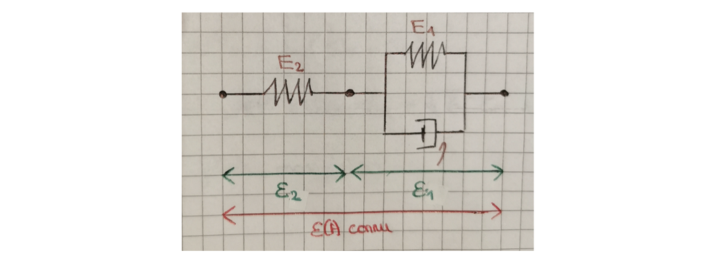

Fig 14: Modèle de Zener: association d'une branche élastique en série au modèle de Voigt

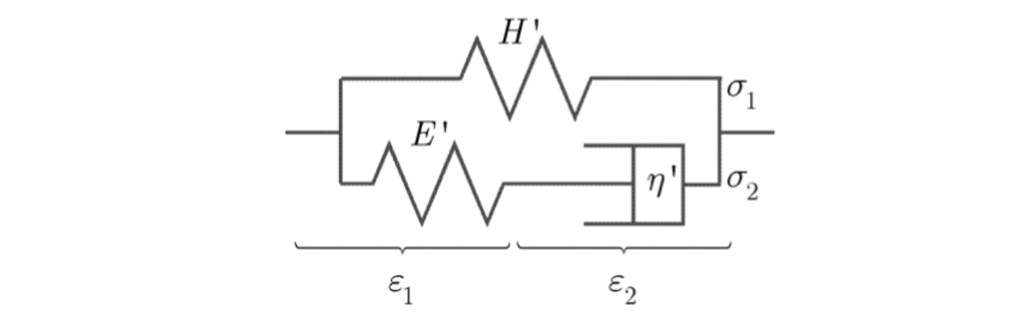

Fig 15: Modèle de Zener: association d'une branche élastique en parallèle au modèle de Maxwell

Dans la suite de notré étude, nous allons considéré la première nomenclature (figure 14), même si rappelons le, les deux modèles sont équivalents